# Developing Data Products - Assingment 4

29-2-2020

## Introduction

This presentation is part of assingment 4 of the Developing Data Products course on Coursera. This presentation supports a shiny app developed for this assingment. This shiny app uses the solubility data to predict the solubility of a compound based on the molecular weight of the compound and the hydrophilic factor of the compound. The shiny app uses a simple linear regression method for the prediction. The shiny app plots the predicted value of the solubility based on molecular weight or on hydrophilic factor on the scatter plot of the solubility data. It also depicts the numerical value of the predictions.

Please make sure the solubility data from the AppliedPredictiveModeling package is loaded into your workspace if you are to reproduce this work.

## The code

The following code is used to calculate the predictions

```r
#Read data
library(AppliedPredictiveModeling); data(solubility)
solubility <- solTrainY; hydrophilicfactor <- solTrainX$HydrophilicFactor
molecularweight <- solTrainX$MolWeight

#Fit models
model1 <- lm(solubility ~ molecularweight); model2 <- lm(solubility ~ hydrophilicfactor)
#Predict with input
model1pred <- reactive({ MWinput <- input$sliderMW; predict(model1, newdata = data.frame(molecularweight = MWinput)) })
model2pred <- reactive({HFinput <- input$sliderHF; predict(model2, newdata = data.frame(hydrophilicfactor = HFinput))
        })
```

## Plot of the original data

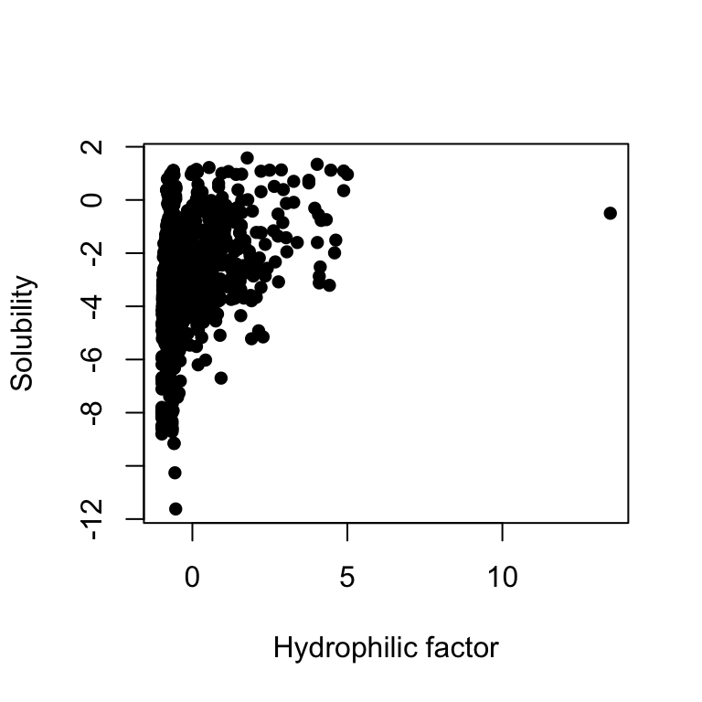

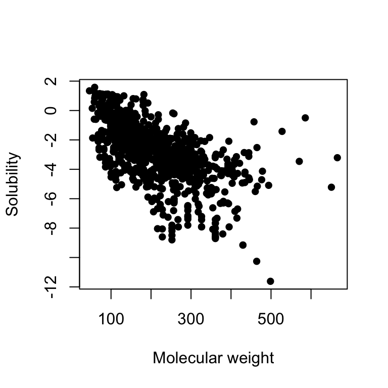

## The shiny app

The Shiny application allows users to enter the value for molecular weight and/or hydrophilic factor to predict the solubility of a compound. The application then outputs the predicted value in the scatter plot with a red circle for molecular weight and a blue circle of hydrophilic factor. It also outputs the predictions to the main panel as a number.

The shiny app is available via the following link: https://littlemeadow1994.shinyapps.io/assignment4/

The code is available via the following link: https://github.com/littlemeadow1994/developingdataproducts/tree/master/docs